# BA Assignment 2

VINAY KACHARAM

2023-10-16

#Loading the Dataset :

```r
setwd("C:/Users/vinay/OneDrive/Desktop/BA R PRO/")
dataframe=read.csv("C:/Users/vinay/OneDrive/Desktop/BA R PRO/Online_Retail.csv")
```

## Loading the library(dplyr)

```r
library(dplyr)
```

## 1.Showing how many transactions are in the dataset for each country :

```r
Total_trans=nrow(dataframe)
Total_trans
```

```
## [1] 541909
```

```r
Tran_count <- dataframe %>% group_by(Country) %>% summarize(Count = n())
Tran_count
```

```
## # A tibble: 38 × 2
##    Country         Count
##    <chr>           <int>
##  1 Australia        1259
##  2 Austria           401
##  3 Bahrain            19
##  4 Belgium          2069
##  5 Brazil             32
##  6 Canada            151
##  7 Channel Islands   758
##  8 Cyprus            622
##  9 Czech Republic     30
## 10 Denmark           389
## # ℹ 28 more rows
```

This is the number of transactions for each country.

#Now Calculate the percentage of the transactions for each country :

```r
country_count_Per <- Tran_count %>% mutate(Percentage = (Count / Total_trans) * 100)
country_count_Per
```

```
## # A tibble: 38 × 3
##    Country         Count Percentage
##    <chr>           <int>      <dbl>
##  1 Australia        1259    0.232
##  2 Austria           401    0.0740
##  3 Bahrain            19    0.00351
##  4 Belgium          2069    0.382
##  5 Brazil             32    0.00591
##  6 Canada            151    0.0279
##  7 Channel Islands   758    0.140
##  8 Cyprus            622    0.115
##  9 Czech Republic     30    0.00554
## 10 Denmark           389    0.0718
## # ℹ 28 more rows
```

This is the percentage of the transactions for each country

#Now Show the countries with more the 1% of total transactions:

```r
country_counts_filter <- country_count_Per %>% filter(Percentage > 1)
country_counts_filter
```

```
## # A tibble: 4 × 3
##   Country         Count Percentage
##   <chr>           <int>      <dbl>
## 1 EIRE             8196       1.51
## 2 France           8557       1.58
## 3 Germany          9495       1.75
## 4 United Kingdom 495478      91.4
```

## 2.Creating a new variable “TransactionValue” by multiplying “Quantity” and “UnitPrice”:

```r
dataframe$TransactionValue <- dataframe$Quantity*dataframe$UnitPrice
head(dataframe)
```

```
##   InvoiceNo StockCode                         Description Quantity
## 1    536365    85123A  WHITE HANGING HEART T-LIGHT HOLDER        6
## 2    536365     71053                 WHITE METAL LANTERN        6
## 3    536365    84406B      CREAM CUPID HEARTS COAT HANGER        8
## 4    536365    84029G KNITTED UNION FLAG HOT WATER BOTTLE        6
## 5    536365    84029E      RED WOOLLY HOTTIE WHITE HEART.        6
## 6    536365     22752        SET 7 BABUSHKA NESTING BOXES        2
##      InvoiceDate UnitPrice CustomerID        Country TransactionValue
## 1 12/1/2010 8:26      2.55      17850 United Kingdom            15.30
## 2 12/1/2010 8:26      3.39      17850 United Kingdom            20.34
## 3 12/1/2010 8:26      2.75      17850 United Kingdom            22.00
## 4 12/1/2010 8:26      3.39      17850 United Kingdom            20.34
## 5 12/1/2010 8:26      3.39      17850 United Kingdom            20.34
## 6 12/1/2010 8:26      7.65      17850 United Kingdom            15.30
```

## 3.Showing the breakdown of transaction values by countries:

```r
country_totals <- dataframe %>% group_by(Country) %>% summarize(TotalValue = sum(TransactionValue))
country_totals
```

```
## # A tibble: 38 × 2
##    Country         TotalValue
##    <chr>                <dbl>
##  1 Australia          137077.
##  2 Austria             10154.
##  3 Bahrain               548.
##  4 Belgium             40911.
##  5 Brazil               1144.
##  6 Canada               3666.
##  7 Channel Islands     20086.
##  8 Cyprus              12946.
##  9 Czech Republic        708.
## 10 Denmark             18768.
## # ℹ 28 more rows
```

#Display only countries with total transaction exceeding 130,000 British Pounds:

```r
filtered_countries <- country_totals %>% filter(TotalValue > 130000)
filtered_countries
```

```
## # A tibble: 6 × 2
##   Country        TotalValue
##   <chr>               <dbl>
## 1 Australia         137077.
## 2 EIRE              263277.
## 3 France            197404.
## 4 Germany           221698.
## 5 Netherlands       284662.
## 6 United Kingdom   8187806.
```

## 4.We are dealing with the InvoiceDate variable: printing the time, date, day of week, month, converting the datatypes of the following as mentioned in the assignment.

```r
Temp=strptime(dataframe$InvoiceDate,format='%m/%d/%Y %H:%M',tz='GMT')
head(Temp)
```

```
## [1] "2010-12-01 08:26:00 GMT" "2010-12-01 08:26:00 GMT"
## [3] "2010-12-01 08:26:00 GMT" "2010-12-01 08:26:00 GMT"
## [5] "2010-12-01 08:26:00 GMT" "2010-12-01 08:26:00 GMT"
```

```r
dataframe$New_Invoice_Date <- as.Date(Temp)
head(dataframe$New_Invoice_Date)
```

```
## [1] "2010-12-01" "2010-12-01" "2010-12-01" "2010-12-01" "2010-12-01"
## [6] "2010-12-01"
```

```r
dataframe$New_Invoice_Date[20000]- dataframe$New_Invoice_Date[10]
```

```
## Time difference of 8 days
```

```r
dataframe$Invoice_Day_Week= weekdays(dataframe$New_Invoice_Date)
head(dataframe$Invoice_Day_Week)
```

```
## [1] "Wednesday" "Wednesday" "Wednesday" "Wednesday" "Wednesday" "Wednesday"
```

```r
dataframe$NewInvoice_Hour = as.numeric(format(Temp, "%H"))
head(dataframe$NewInvoice_Hour)
```

```
## [1] 8 8 8 8 8 8
```

```r
dataframe$New_Invoice_Month = as.numeric(format(Temp, "%m"))
head(dataframe$New_Invoice_Month)
```

```
## [1] 12 12 12 12 12 12
```

##(a) Show the percentage of transactions by days of the week

```r
weekday_count = dataframe %>% group_by(Invoice_Day_Week) %>%
summarise(percent = 100* n()/nrow(dataframe))
weekday_count
```

```
## # A tibble: 6 × 2
##   Invoice_Day_Week percent
##   <chr>              <dbl>
## 1 Friday              15.2
## 2 Monday              17.6
## 3 Sunday              11.9
## 4 Thursday            19.2
## 5 Tuesday             18.8
## 6 Wednesday           17.5
```

##(b) Show the percentage of transactions (by transaction volume) by days of the week

```r
weekdays_sum = dataframe %>% group_by(Invoice_Day_Week) %>% summarise(sum=sum(TransactionValue))
weekdays_sum_per = 100*(weekdays_sum$sum)/sum(weekdays_sum$sum)
weekdays_sum$sum = weekdays_sum_per
weekdays_sum
```

```
## # A tibble: 6 × 2
##   Invoice_Day_Week   sum
##   <chr>            <dbl>
## 1 Friday           15.8
## 2 Monday           16.3
## 3 Sunday            8.27
## 4 Thursday         21.7
## 5 Tuesday          20.2
## 6 Wednesday        17.8
```

##(c) Show the percentage of transactions (by transaction volume) by month of the year

```r
Invoice_per_month = dataframe %>% group_by(New_Invoice_Month) %>% summarise(sum=sum(TransactionValue))
Month_per = 100*(Invoice_per_month$sum)/sum(Invoice_per_month$sum)
Invoice_per_month$sum = Month_per
Invoice_per_month
```

```
## # A tibble: 12 × 2
##    New_Invoice_Month   sum
##                <dbl> <dbl>
##  1                 1  5.74
##  2                 2  5.11
##  3                 3  7.01
##  4                 4  5.06
##  5                 5  7.42
##  6                 6  7.09
##  7                 7  6.99
##  8                 8  7.00
##  9                 9 10.5
## 10                10 11.0
## 11                11 15.0
## 12                12 12.1
```

##(d) The highest number of transactions from Australia with date

```r
Australia_trans = dataframe %>% filter(Country == "Australia") %>% group_by(New_Invoice_Date) %>% summarise(total=n())
Aus_Max_trans_dt = Australia_trans[which.max(Australia_trans$total),]
Aus_Max_trans_dt
```

```
## # A tibble: 1 × 2
##   New_Invoice_Date total
##   <date>           <int>
## 1 2011-06-15         139
```

## 5.Plot the histogram of transaction values from Germany:

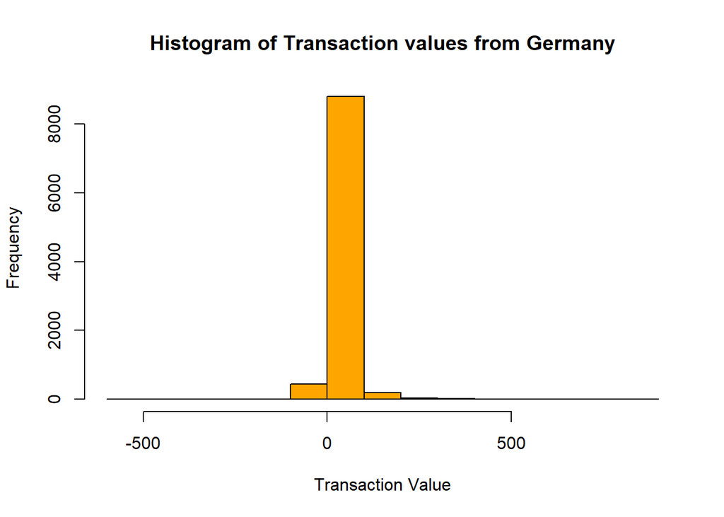

```r
Trans_germ=dataframe[dataframe$Country=="Germany",]
Tranval_germ=Trans_germ$TransactionValue

hist(Tranval_germ,main="Histogram of Transaction values from Germany",xlab="Transaction Value",ylab="Frequency",col="orange",border="black")
```

## 6.Find Which customer had the highest number of transactions :

```r
no_of_trans=table(dataframe$CustomerID)
High_no_of_trans=names(which.max(no_of_trans))
High_no_of_trans
```

```
## [1] "17841"
```

#Find the most valuable customer i.e.,the customer with highest total sum of transactions:

```r
sum_trans_cust <- tapply(dataframe$TransactionValue, dataframe$CustomerID, sum)
most_val_cust <- names(which.max(sum_trans_cust))
print(most_val_cust)
```

```
## [1] "14646"
```

## 7.Calculate the percentage of missing values for each variable in the dataset:

```r
NA_per = colMeans(is.na(dataframe))*100
NA_per
```

```
##         InvoiceNo         StockCode       Description          Quantity
##           0.00000           0.00000           0.00000           0.00000
##       InvoiceDate         UnitPrice        CustomerID           Country
##           0.00000           0.00000          24.92669           0.00000
##  TransactionValue  New_Invoice_Date  Invoice_Day_Week   NewInvoice_Hour
##           0.00000           0.00000           0.00000           0.00000
## New_Invoice_Month
##           0.00000
```

## 8.The number of transactions with missing CustomerID records by countries :

```r
NA_Cust = dataframe[is.na(dataframe$CustomerID),]
table(NA_Cust$Country)
```

```
##
##        Bahrain           EIRE         France      Hong Kong         Israel
##              2            711             66            288             47
##       Portugal    Switzerland United Kingdom    Unspecified
##             39            125         133600            202
```

## 9.the costumers comeback to the website for their next shopping

```r
Come_back <- table (dataframe$Invoice_Day_Week,dataframe$New_Invoice_Date)
Come_back_New<- diff(Come_back)
mean(Come_back_New)
```

```
## [1] 8.112787
```

## 10.Calculate The return rate for the French customers:

```r
Fren_cust = filter(dataframe,Country=="France" )
Rate_return = nrow(filter(Fren_cust,Quantity<1))/nrow(Fren_cust)
Rate_return
```

```
## [1] 0.01741264
```

## 11.The product that has generated the highest revenue for the retailer:

```r
Highreve_product= dataframe %>% group_by(StockCode) %>% summarise(Sum_trnsval = sum(TransactionValue))
Highreve_product[which.max(Highreve_product$Sum_trnsval),]
```

```
## # A tibble: 1 × 2
##   StockCode Sum_trnsval
##   <chr>           <dbl>
## 1 DOT           206245.
```

## 12. The unique customers are represented in the dataset:

```r
length(unique(dataframe$CustomerID))
```

```
## [1] 4373
```